# PCAs of mC in 100 kbp bins

Tomato TET3 BS-seq screening test

Javier Antúnez Sánchez

September 2022

Analysis of DNA methylation in 100 kbp bins created with `CX_report2mC_bins.v1.0.pl` from Bismark CX_reports.

# Load data

When loading data we filter chromosome 9 as there is an anomaly in the mapping (and extranuclear genomes), and samples A1_2, B2_13, neg, PBS & Undetermined, as they are the controls, the reads that couldn’t be assigned to any library, and 2 samples with almost no reads

# PCAs

### CG PCA table

#### show table

| sample | PC1 [8%] | PC2 [8%] | PC3 [6%] | PC4 [4%] | PC5 [3%] | PC6 [3%] | PC7 [3%] | PC8 [3%] | PC9 [3%] | PC10 [3%] | PC11 [3%] | PC12 [2%] | PC13 [2%] | PC14 [2%] | PC15 [2%] | PC16 [2%] | PC17 [2%] | PC18 [2%] | PC19 [2%] | PC20 [2%] | PC21 [2%] | PC22 [2%] | PC23 [2%] | PC24 [2%] | PC25 [2%] | PC26 [2%] | PC27 [2%] | PC28 [2%] | PC29 [2%] | … |
| --- | --- | --- | --- | --- | --- | --- | --- | --- | --- | --- | --- | --- | --- | --- | --- | --- | --- | --- | --- | --- | --- | --- | --- | --- | --- | --- | --- | --- | --- | --- |
| A11_10 | -17.3026958 | 6.1451016 | -16.162242 | -33.839389 | 5.2816063 | -20.6266316 | 8.4033177 | -9.9283830 | 2.306871e+00 | 1.868833 | -29.0453174 | -6.2728987 | 16.857036 | 4.469322 | 5.338168 | -7.329337 | -24.8209032 | 8.0004314 | 17.1638578 | 13.388374 | 18.7538254 | -2.292357 | -21.4911416 | 20.3121540 | 16.7102777 | 11.178951 | 9.5473642 | -11.5079703 | -1.498644e+01 | … |
| A11_11 | -11.6818259 | 18.2554195 | -18.464144 | -20.110548 | 18.2100336 | -11.2340528 | 6.9313721 | 0.9561730 | 1.147114e+01 | 19.585030 | -5.4348818 | 1.6620105 | 4.749508 | -8.445451 | 10.783805 | 10.164816 | -7.9817453 | 5.1158458 | 15.9555181 | -1.105447 | 8.0231068 | -8.311964 | -14.7891687 | 3.5498641 | 15.0959293 | 12.214883 | -19.2523032 | -4.5304679 | -2.662565e+01 | … |
| A11_3 | -13.5806884 | 23.6836211 | 40.836091 | 7.964735 | 12.5363058 | 5.7055104 | 8.3762334 | -8.4476857 | -3.585087e+01 | 31.548743 | -10.0053278 | -41.0208764 | 44.359304 | -39.989366 | -34.084513 | -40.309399 | -30.0651227 | 19.1556462 | 27.9410133 | -24.020406 | 18.9705885 | 22.068506 | -83.7555261 | -53.3012644 | 14.7899433 | -54.525348 | -236.3942659 | 33.7739953 | -8.700461e+01 | … |
| A11_5 | -13.1660160 | 10.5392273 | 11.098892 | -22.008584 | 15.1752370 | -1.7862734 | -5.3873391 | -13.8543723 | -8.966771e+00 | -18.838260 | -10.2550762 | -17.2718696 | 13.652339 | -24.440339 | -35.207995 | 21.653129 | -2.4619562 | -11.9678547 | 32.2435207 | 31.070528 | 33.8179149 | -26.500301 | -75.0803320 | -8.7900535 | 45.8465653 | -69.679792 | 61.3781480 | 64.2212340 | 3.858548e+01 | … |
| A11_8 | -12.9194523 | -5.7955443 | -13.019331 | -36.750727 | 10.0468795 | 43.3471553 | -18.2355898 | 79.0291862 | 3.221465e+01 | 118.656332 | -104.7802023 | -171.6209878 | -6.475876 | -210.429439 | -30.213011 | -21.331493 | -2.2338448 | 61.3323684 | -12.2867232 | 66.289465 | -31.6717527 | 23.807612 | 76.6797774 | -28.5721864 | -51.8089782 | 18.657013 | 38.5209177 | -26.2805991 | -1.675535e+01 | … |
| A_12 | -38.7011280 | 9.8973471 | 31.104502 | -31.429510 | 31.2935564 | 52.5252707 | 30.1742097 | -227.8950550 | -1.787287e+02 | 86.556485 | -157.6468873 | 15.3309361 | -4.145702 | 42.069595 | 86.617671 | -22.347499 | -28.6451785 | 26.6439801 | -32.1586407 | -59.995908 | -40.2266113 | -28.757852 | 36.9664392 | 4.0665603 | -11.1543072 | 6.776950 | 24.4864646 | 24.0592426 | -5.347203e+00 | … |
| A_14 | -14.5292645 | 35.6867986 | -53.937479 | -36.221862 | 21.1007644 | -0.9837679 | -0.4147957 | -15.1608158 | 1.473272e+00 | 8.288485 | -22.5194866 | 11.2831979 | 19.504723 | 1.725029 | -25.391951 | 15.971006 | 0.7113697 | 14.5990889 | 24.7401314 | -5.421358 | 12.0734614 | -11.206623 | -41.3596743 | 8.0312648 | 26.4333700 | -14.736328 | 1.8227583 | 3.2239040 | -1.407514e+01 | … |
| A1_4 | -30.9359991 | 16.4821311 | 21.320528 | -19.901912 | 16.8637140 | -3.0614753 | 6.9787713 | -15.8173676 | 1.361831e+01 | 26.703884 | 8.7228631 | 8.7516245 | 7.741955 | -5.724352 | -4.350825 | -4.055515 | 3.8450806 | 6.5407656 | -14.6907474 | 8.605530 | 19.4918902 | -8.321620 | -16.6044838 | -18.4021515 | 0.8606234 | -14.310534 | 23.2482218 | -50.7927809 | 3.295720e+01 | … |
| A_15 | -14.2871578 | 14.8139787 | -23.311825 | -17.630822 | 15.6035551 | -10.0845314 | 7.4810982 | 3.4519922 | -8.830668e+00 | 7.656725 | -6.1405419 | -13.9693082 | 18.583154 | -7.627646 | -10.059402 | 7.977830 | -8.3486238 | 5.4040149 | -4.4780218 | -9.794671 | -1.6430810 | 6.349772 | -18.2129199 | 13.9753501 | 25.7896973 | 14.414919 | -4.7840313 | -9.3391750 | -8.012527e+00 | … |
| A1_6 | -22.4208414 | 32.9023433 | -15.620898 | -33.426680 | 6.6883406 | -19.3185448 | 13.5009938 | 17.2154274 | 2.878451e+01 | -3.553705 | -50.3458337 | -10.9046015 | -18.359650 | -24.849324 | -5.262787 | -8.846920 | -11.1429353 | 14.4879077 | 59.6430500 | 25.836334 | 48.3402128 | -44.753031 | -110.6564180 | -35.8244862 | 69.2862368 | 96.055709 | -20.9767101 | 51.4939466 | 1.421981e+02 | … |

[output cut: 34 more lines]

# Using the PCAs to remove ouliers

We can identify outlier samples by looking at the PCAs, those samples that constitute one Principal Component on their own will probably be outliers. As this is a very lo coverage Whole Genome Bisulfite Sequencing, I suspect most of the variation that is not biological will come from the depth of sequencing, which varies between our samples, so I will use the number of Cytosines covered in the Mapping as a threshold to discard outliers.

## > 1 Million Cs

We start with the samples with more than 1 Million Cytosines (meaning that we have already discarded before samples A1_2 & B2_13, which have almost no reads mapping, 34 and 8901 respectively)

Most of the dispersion (except in CHH) is due to those samples with lowest coverage (B2_18 & B2_20)

### mC

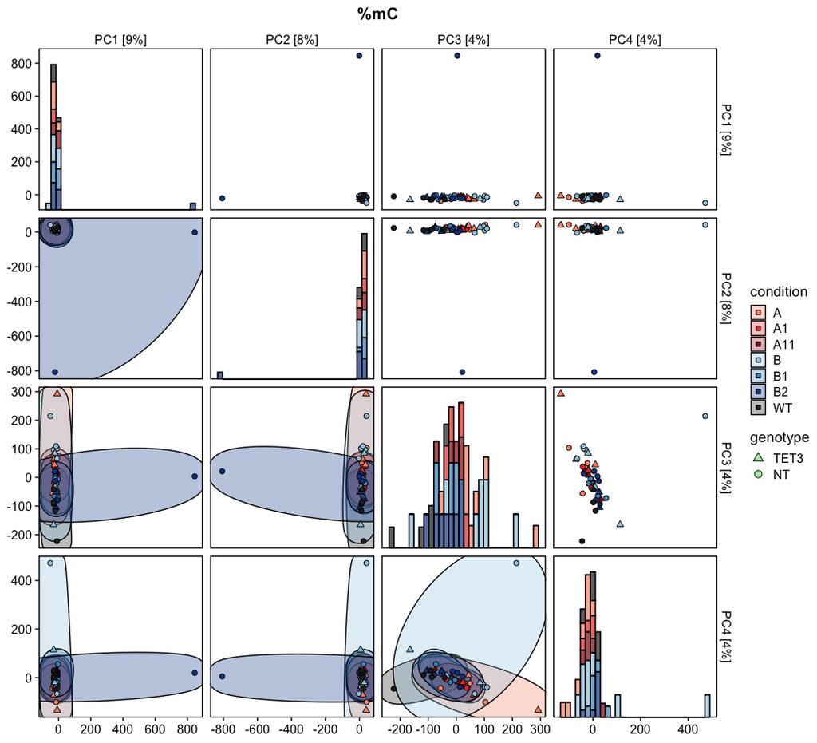

### mCG

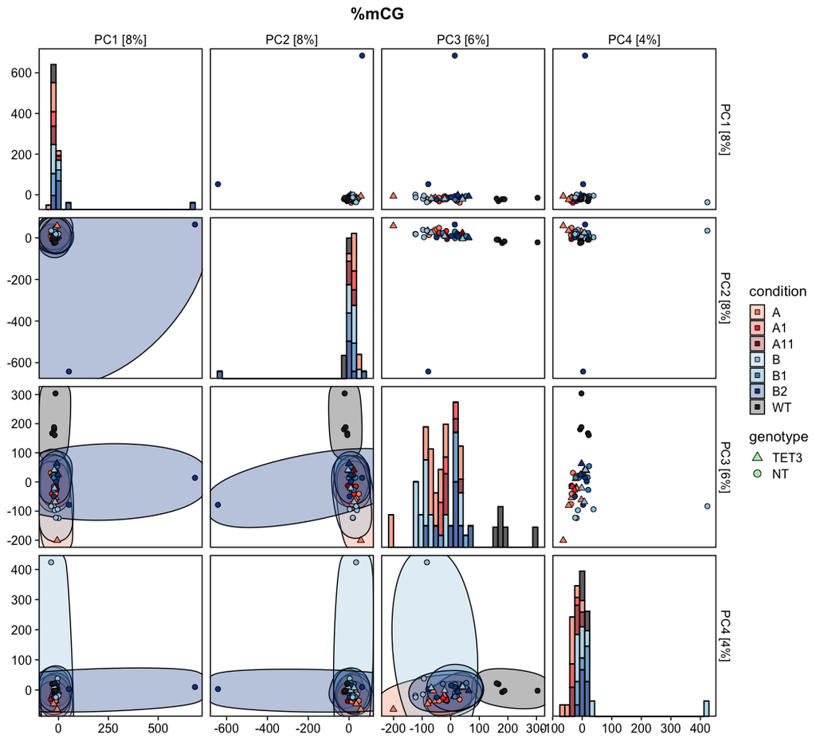

### mCHG

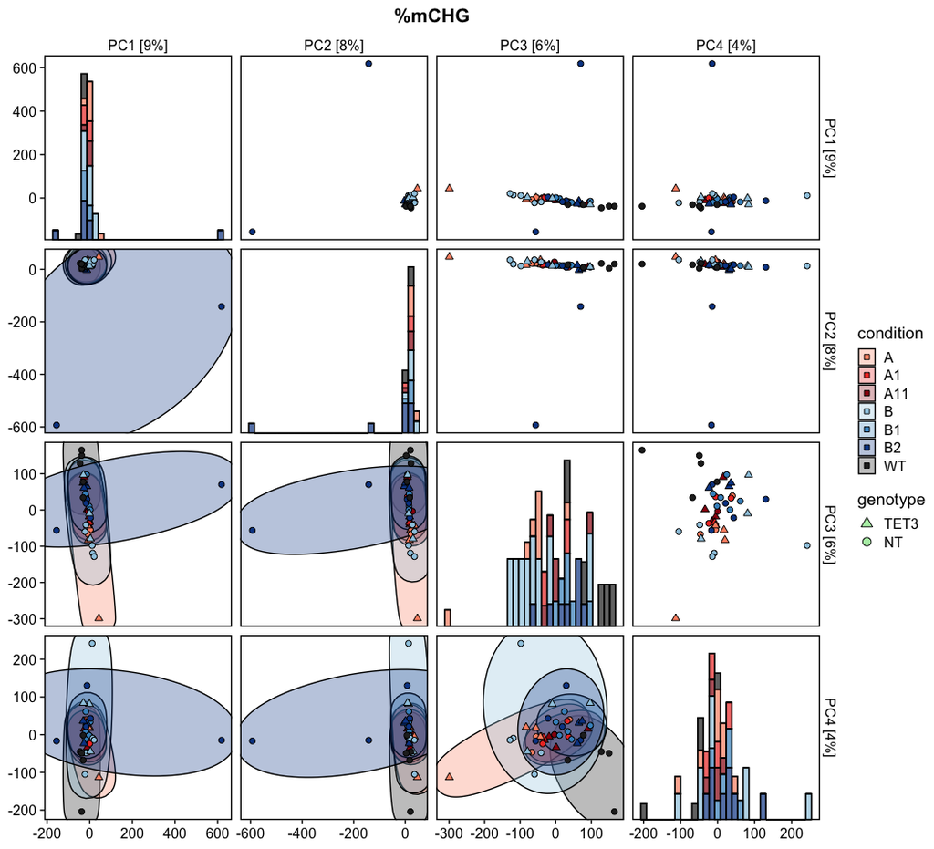

### mCHH

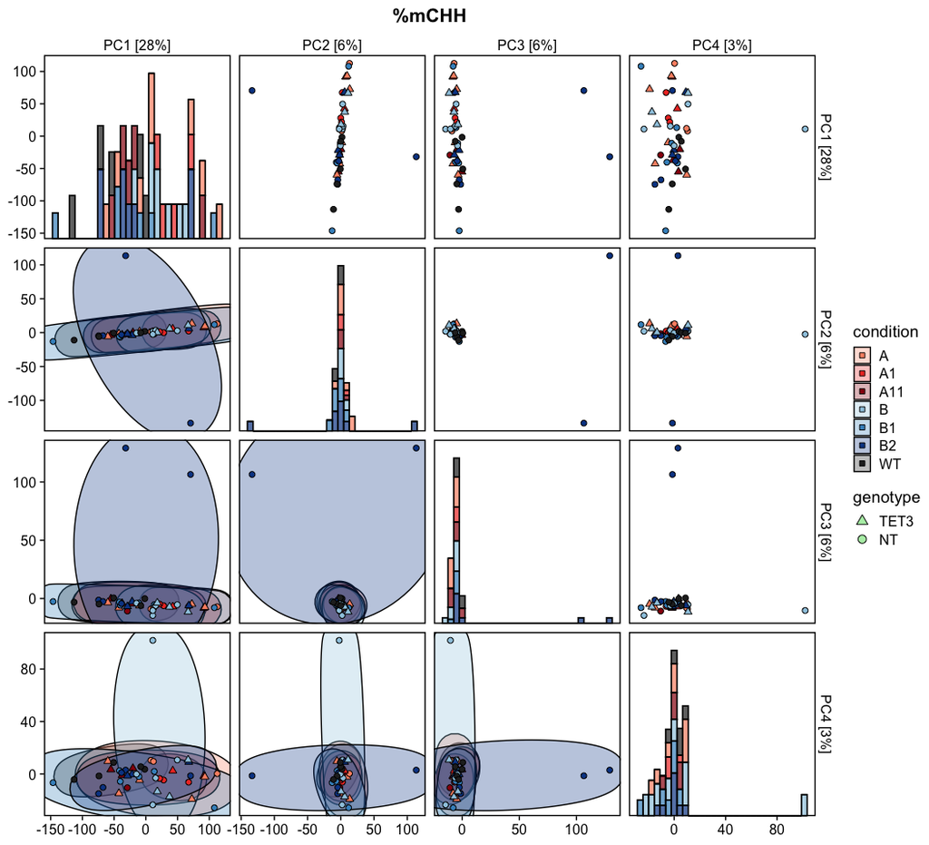

## > 11 Million Cs

B_6 & B_11 have less than 11 M Cs

### mC

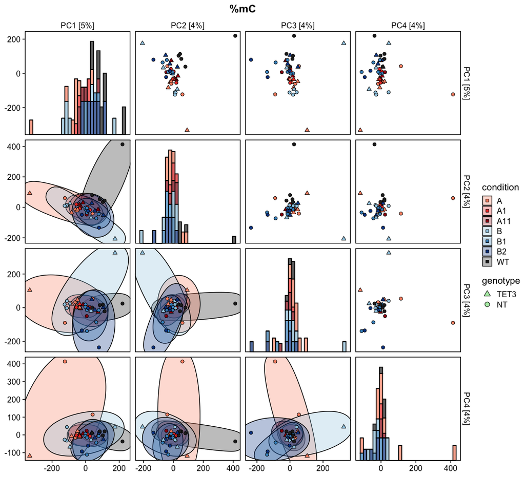

### mCG

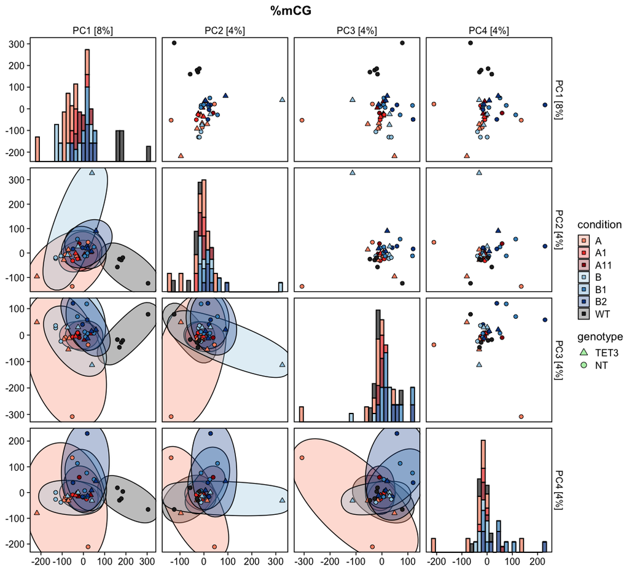

### mCHG

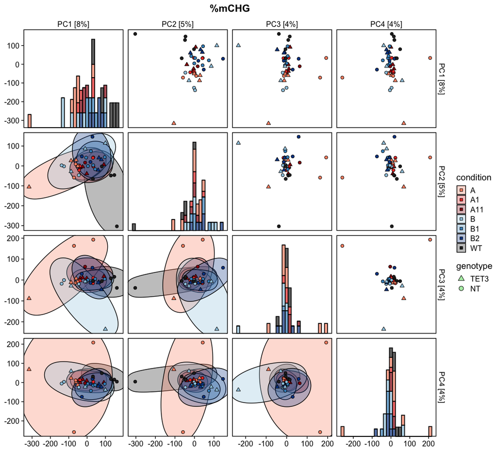

### mCHH

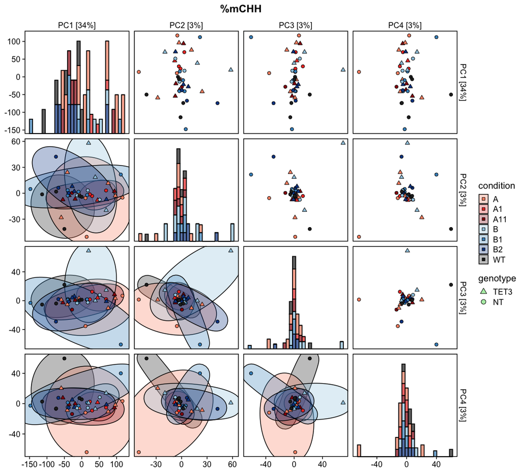

## > 12 Million Cs

WT_6 & B_5 have less than 12 M Cs

### mC

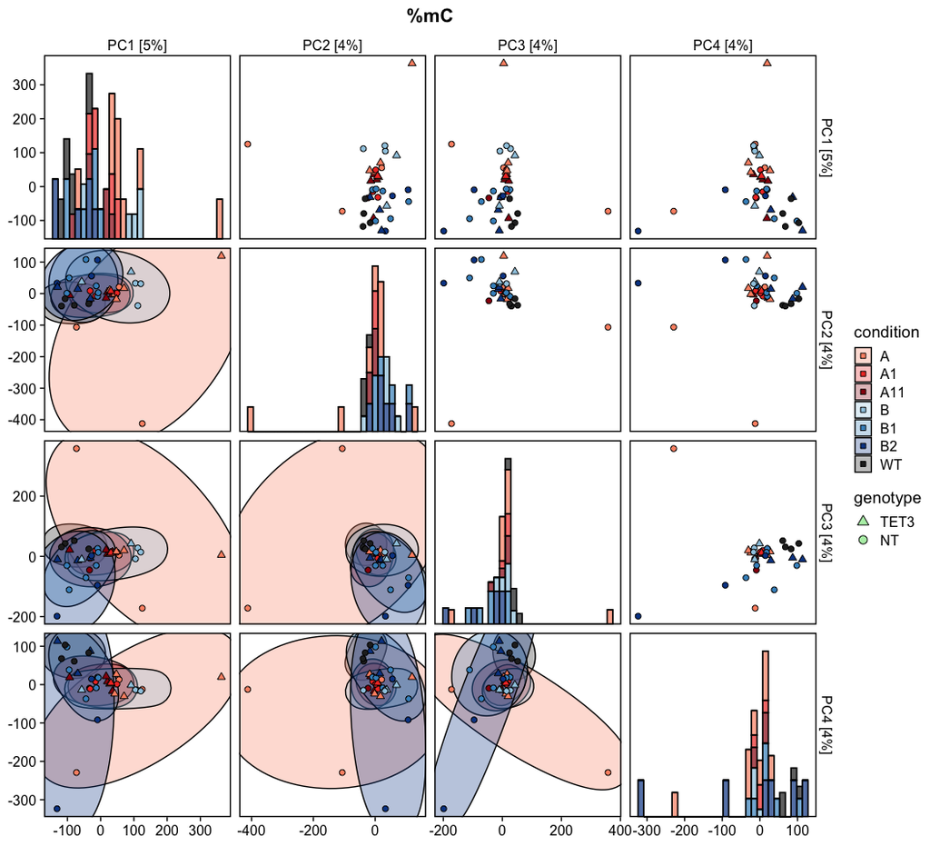

### mCG

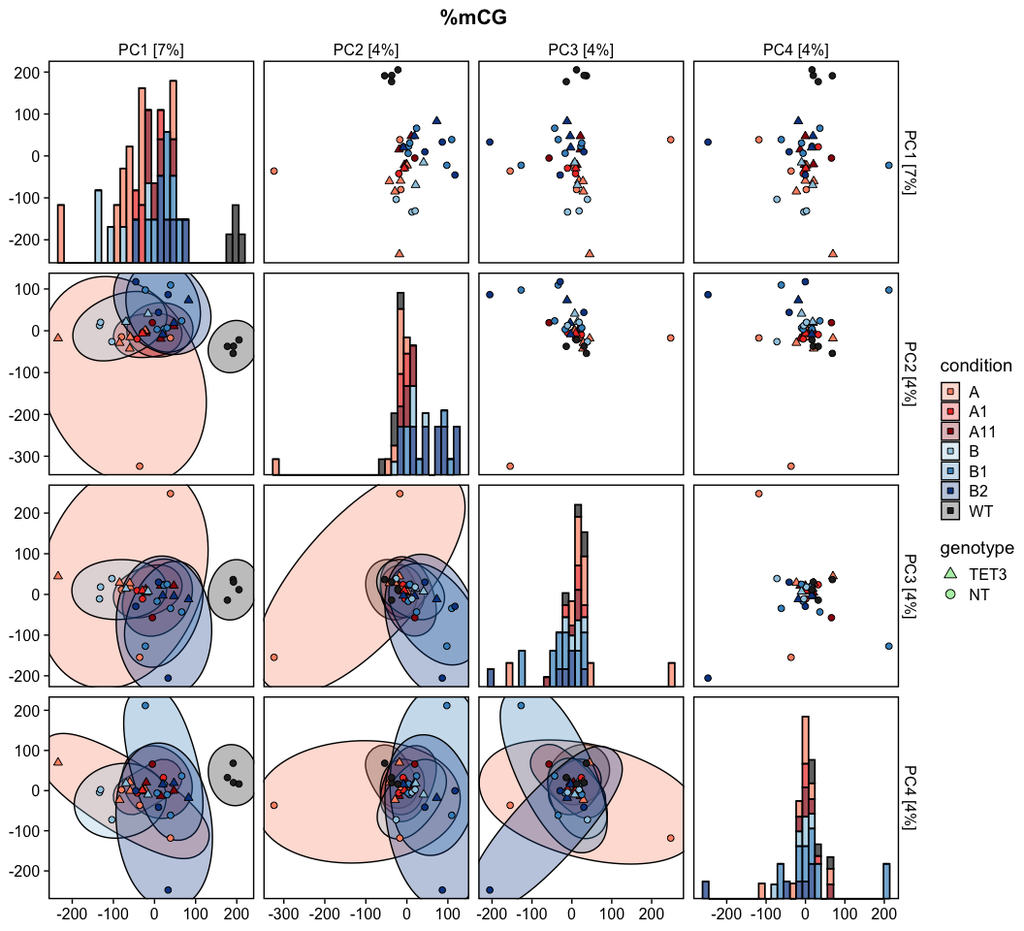

### mCHG

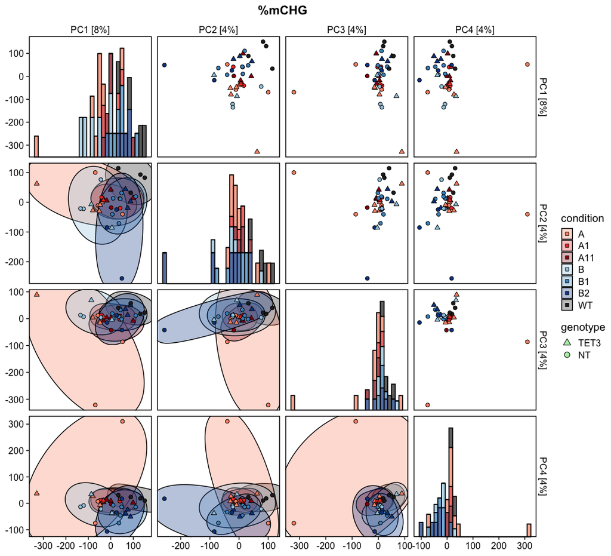

### mCHH

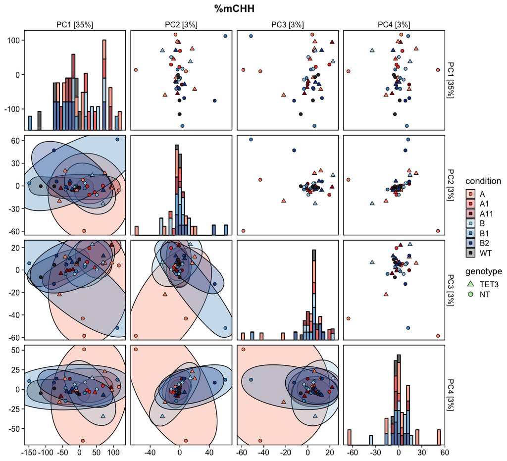

## > 13 Million Cs

A_1 have less than 13 M Cs

### mC

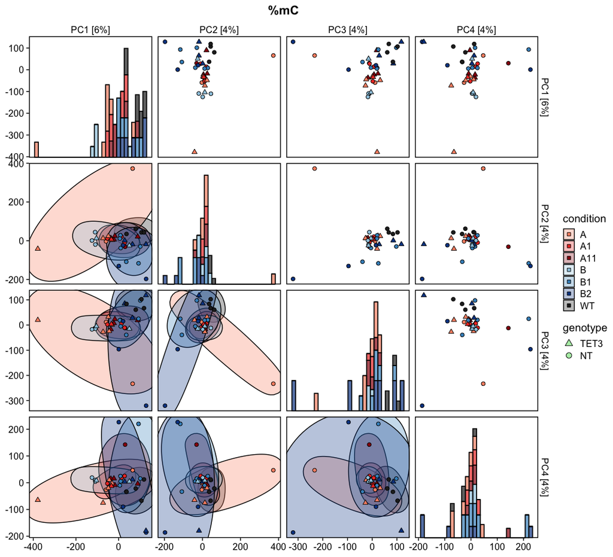

### mCG

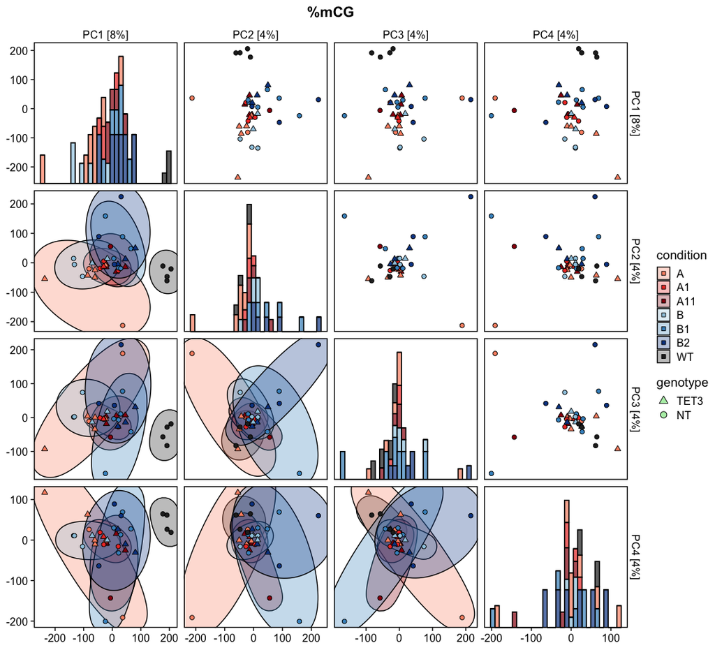

### mCHG

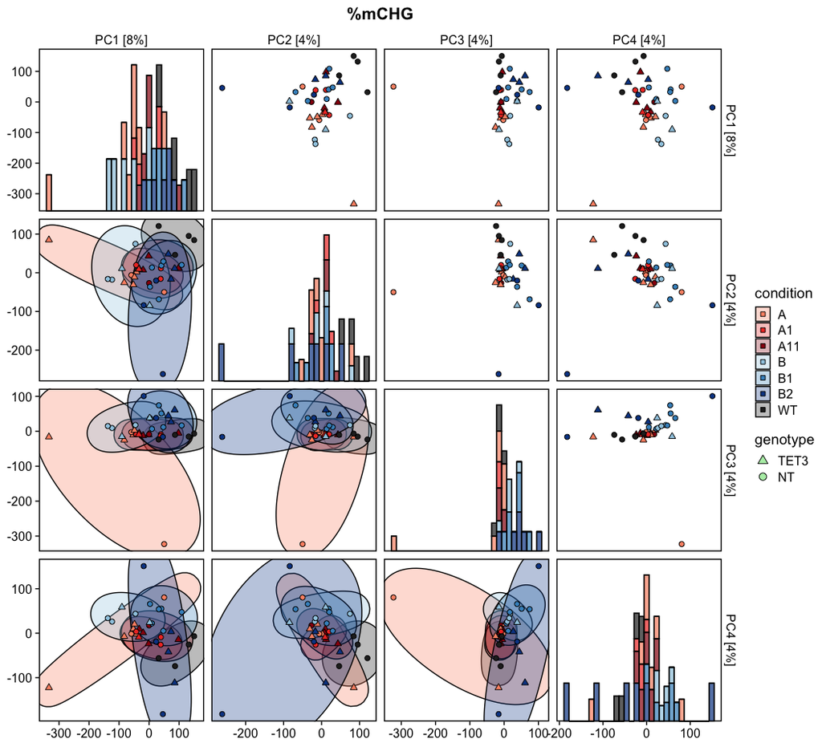

### mCHH

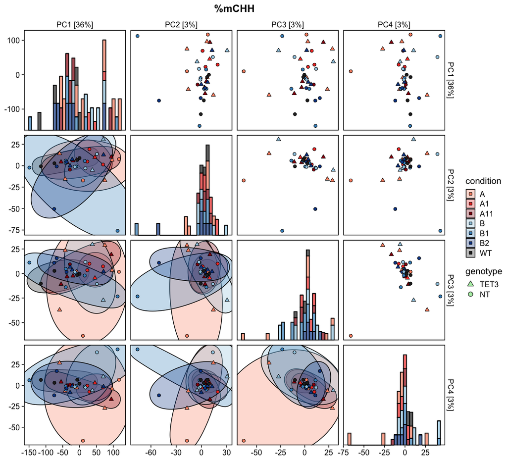

## > 14 Million Cs

A_12, B1_2 & B2_14 have less than 14 M Cs

### mC

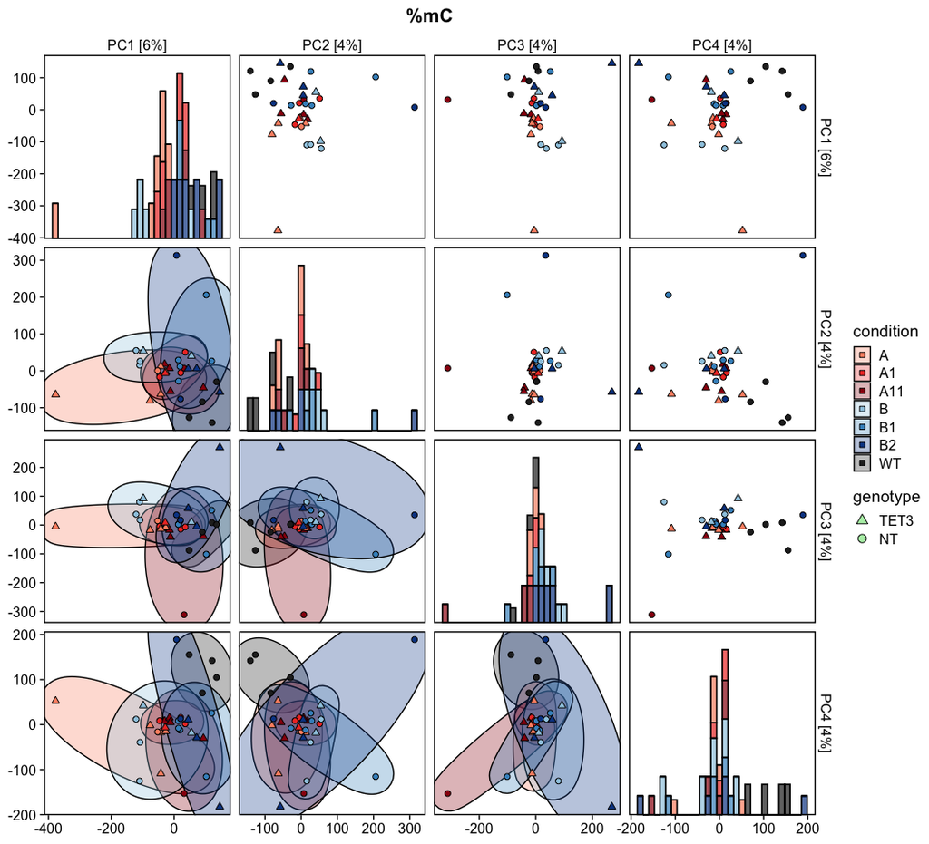

### mCG

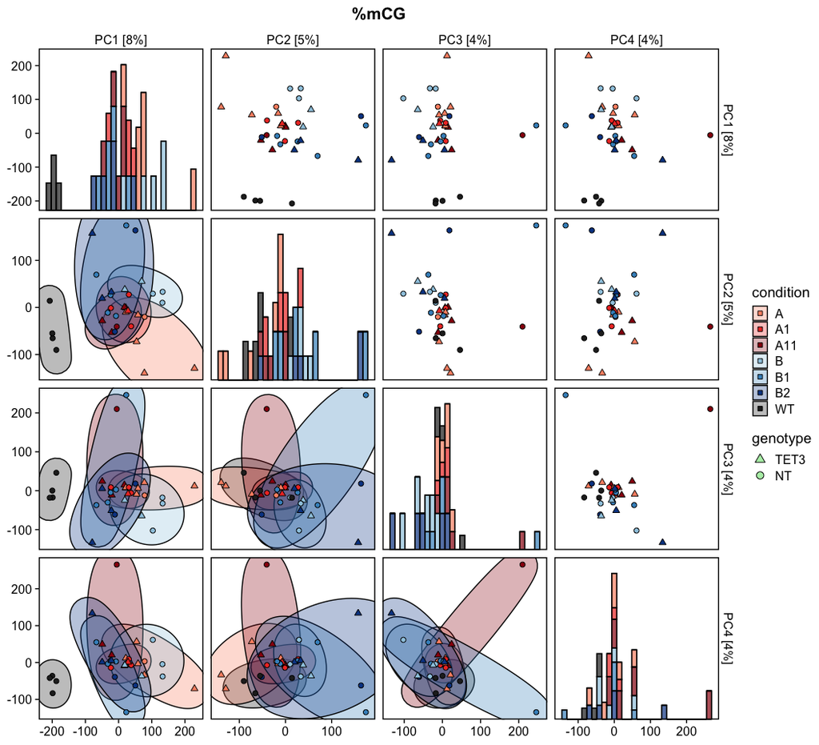

### mCHG

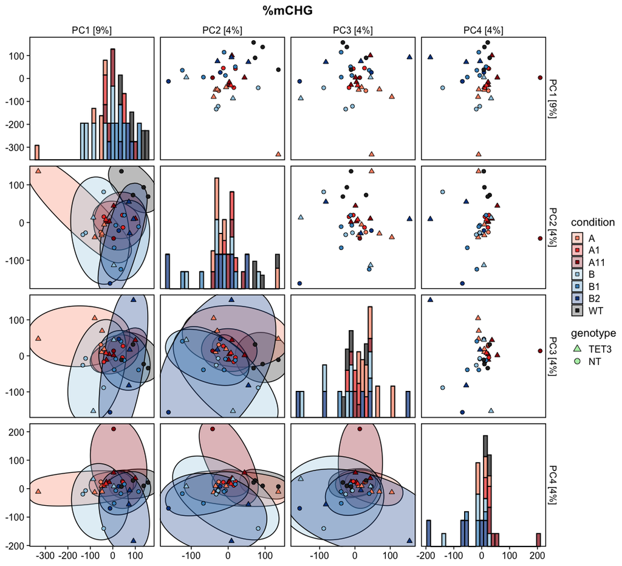

### mCHH

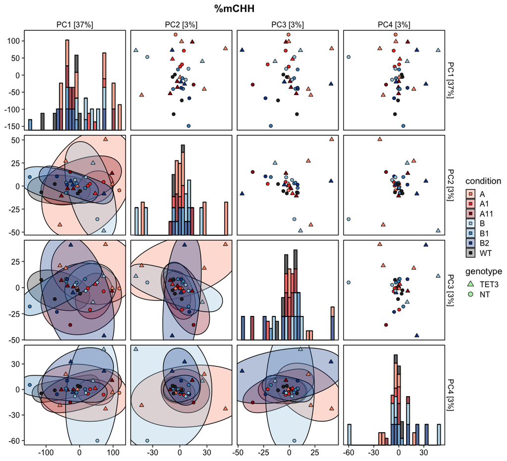

## > 15 Million Cs

B1_7 & B2_16 have less than 15 M Cs

After removing those last 2 samples there doesn’t seem to be an improvement in the PCAs

### mC

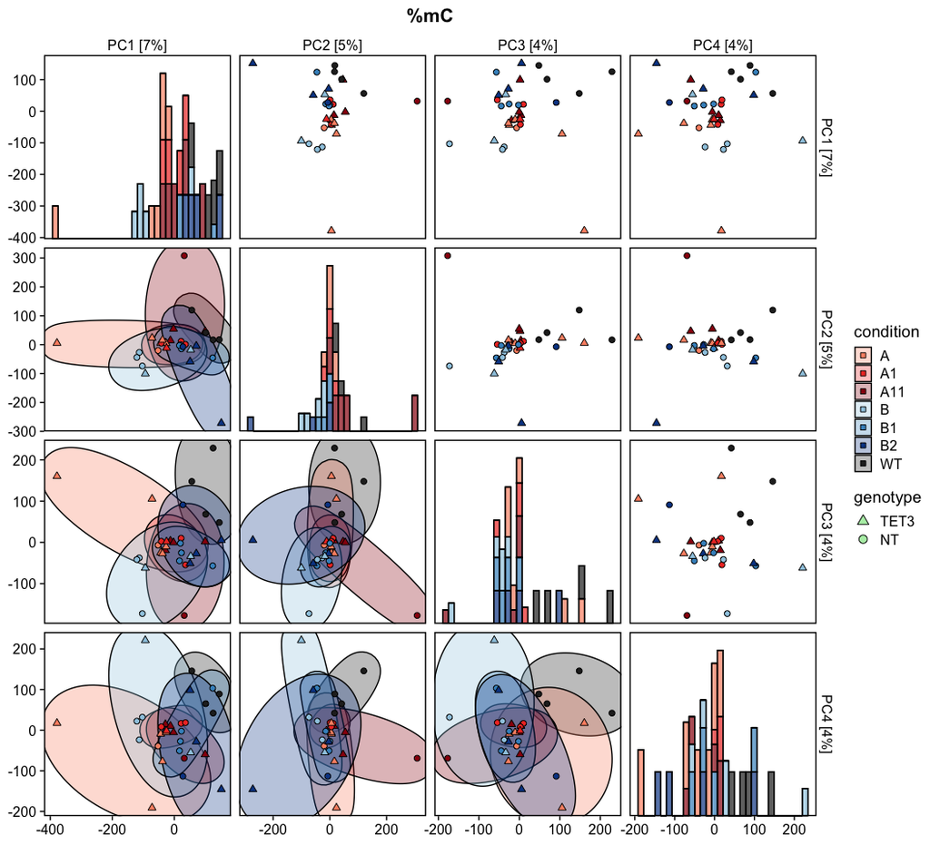

### mCG

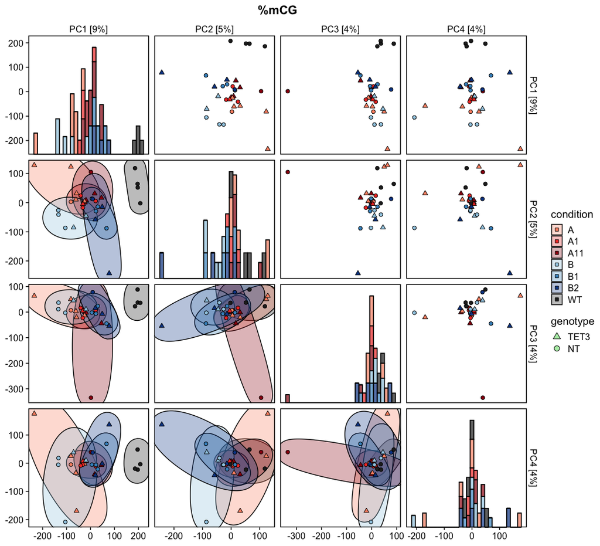

### mCHG

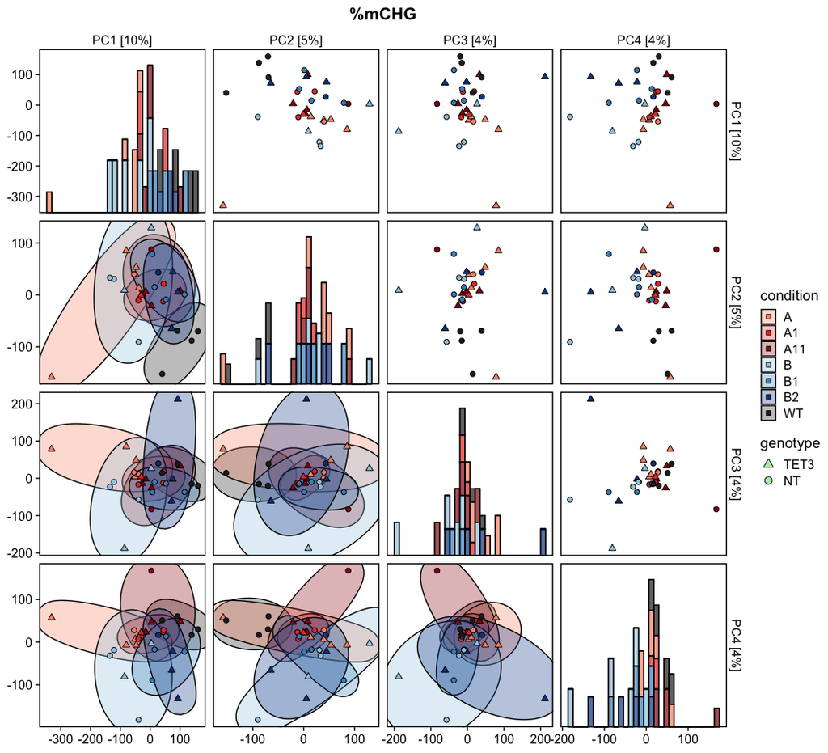

### mCHH

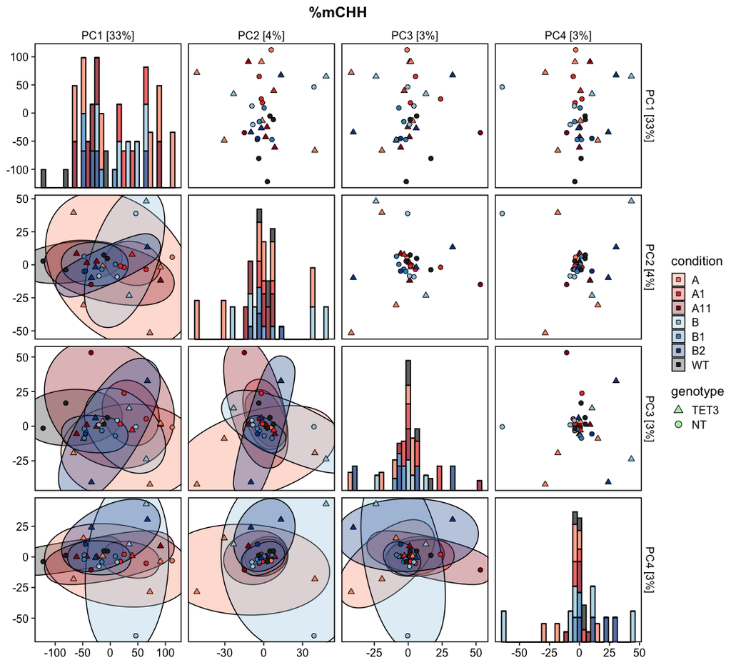

# Final set of samples

Previously I had used the threshold of 15 Million Cs covered to discard some samples and make the PCAs of 100 kbp bins less noisy. After having another go at the PCAs I think it is better to use **14 Million Cs**. This way I keep more 2 more samples for the analysis and they don’t seem to be outliers.

### PCA CG context

After filtering low coverage samples, PCA plots show interesting patterns for CG context:

- PC1 (8%) separates WT from TET3 plants, with the first generation sublines being further away from the WTs,
- PC2 (5%) separates Line B from Line A and WT, and line A T1expands beyond WT range

#### ellipses

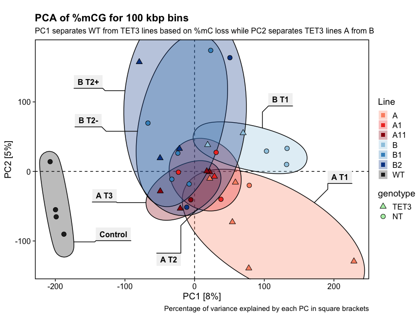

#### hulls

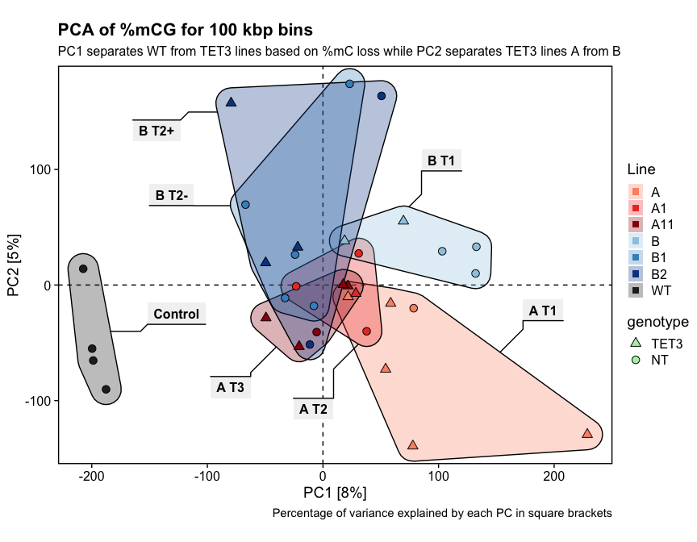

# Correlation between PC1 and %mC

From the PCAs there seems to be a correlation between CG methylation loss and position across the PC1. To check if it is true I compared the average methylation across the genome (mean of all 100 kbp bins) to the position across PC1 and calculate the correlation using a linear model. The Pearson correlation coeficient is 0.99, so PC1 is reflecting global CG methylation levels. I tried this for the other context and the correation is also perfect, even in CHH, which has a lot of varince captured in PC1 (37%) but that doesn’t separete the samples by group.

## CG

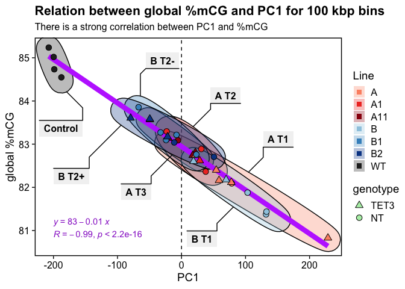

## CHG

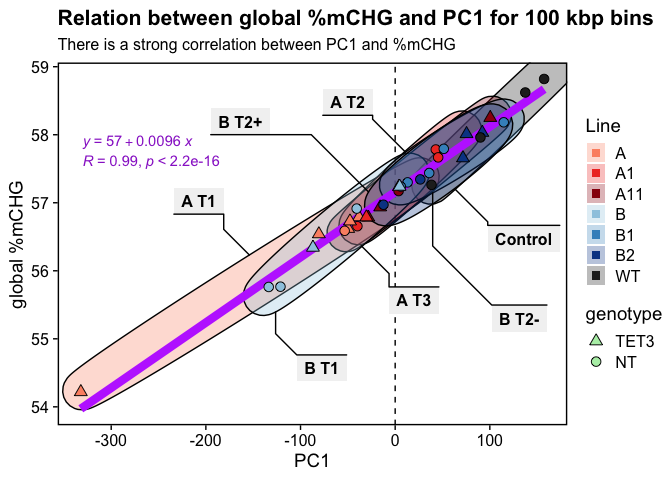

## CHH

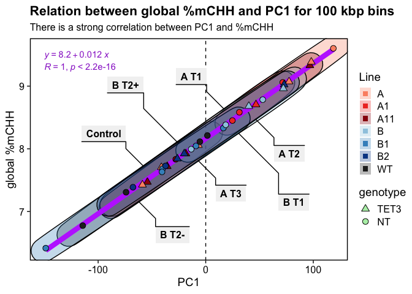

# PCAs split by chromatin

Now I would like to check if the patterns hold equally for Heterochromatin and Euchromatin

Using information about location of boundaries between euchromatin and heterochromatin inferred from H3K27mac ChIP-seq data, we can compare the changes in DNA methylation between the two compartments of the genome.

For CG context, which had the clearest separation of samples before splitting for chromatin, the pattern is lost for the Euchromatin bins, with the PCs not clustering samples, while for Heterochromatin the pattern is maintained.

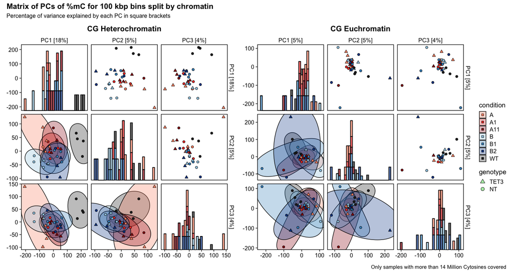

### PCA CG context in Heterochromatin

CG context PC1 accounts for 18% of the variance in Heterocrhomatin, instead of 8% for the whole genome. This suggests that most of the methylation differences (that explain PC1) are concentrated in heterochromatic regions of the genome.

#### ellipses

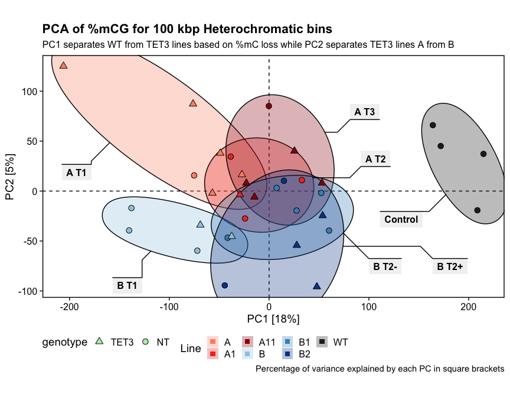

#### hulls

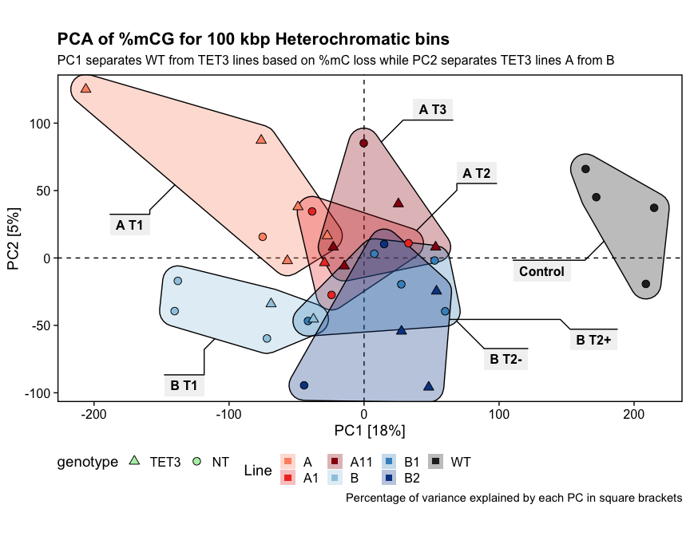